# Lab 2

Malik Bulur

9/10/2020

```r
library(ggplot2)
choco <- read.csv("https://raw.githubusercontent.com/xdaiISU/ds202materials/master/hwlabs/data/choco.csv")
str(choco)
```

```
## 'data.frame':    2312 obs. of  13 variables:
##  $ REF                 : int  2454 2458 2454 797 797 1015 1019 1011 1019 1011 ...
##  $ Company             : chr  "5150" "5150" "5150" "A. Morin" ...
##  $ Location            : chr  "U.S.A." "U.S.A." "U.S.A." "France" ...
##  $ Date                : int  2019 2019 2019 2012 2012 2013 2013 2013 2013 2013 ...
##  $ Bean_Origin         : chr  "Madagascar" "Dominican Republic" "Tanzania" "Peru" ...
##  $ Specific_Bean_Origin: chr  "Bejofo Estate, batch 1" "Zorzal, batch 1" "Kokoa Kamili, batch 1" "Peru" ...
##  $ Cocoa_Percent       : num  76 76 76 63 70 70 63 70 70 70 ...
##  $ Ingredients         : chr  "3- B,S,C" "3- B,S,C" "3- B,S,C" "4- B,S,C,L" ...
##  $ Characteristics1    : chr  "cocoa" "cocoa" "rich cocoa" "fruity" ...
##  $ Characteristics2    : chr  "blackberry" "vegetal" "fatty" "melon" ...
##  $ Characteristics3    : chr  "full body" "savory" "bready" "roasty" ...
##  $ Characteristics4    : chr  NA NA NA NA ...
##  $ Rating              : num  3.75 3.5 3.25 3.75 3.5 4 4 3.75 3.5 3.25 ...
```

#### 1. How are the ratings distributed?

The histogram shows that the ratings are skewed towards the left. This means that as the rating’s value increases so does the frequency of the ratings. As the rating’s value decreases then the frequency goes down also. Around the 2.50 rating value is when the frequency has major upward movement in the frequency versus its predecessors’ ratings which seem to oscillate between 0 and 40 in frequency. When looking at the boxplot for the distribution of the ratings it can be seen that the average rating is at 3.25, the 25th percentile is 3.00, the 75th percentile is at 3.50, the lowest rating is 1.00, and the highest rating is 4.00.

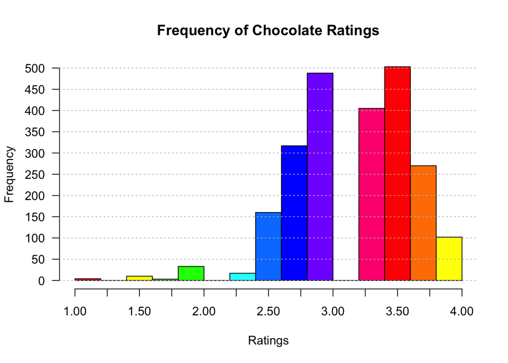

```r
hist(choco$Rating, main="Frequency of Chocolate Ratings", xlab="Ratings", xlim=c(1, max(choco$Rating)), xaxp=c(1, max(choco$Rating), 12), ylim=c(0, 500), yaxp=c(0, 500, 10), col=rainbow(12), las=1)
abline(h=seq(0, 500, 50), col="grey", lty="dotted")
```

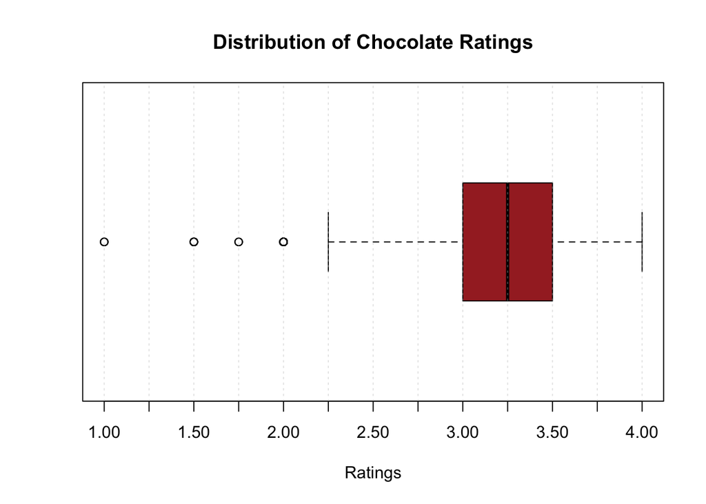

```r
boxplot(choco$Rating, horizontal=TRUE, main="Distribution of Chocolate Ratings", xlab="Ratings", xaxp=c(1, max(choco$Rating), 12), col="brown", border="black")
abline(v=seq(1, max(choco$Rating), 0.25), col=alpha("grey", 0.4), lty="dotted")
```

#### 2. How does the number of ratings depend on the year?

From 2006 to 2015 it can be seen there is a general upwards movement in the number of ratings as the years progress. But from 2015 and onward there is no real correlation that can be seen since the movement downward is not a solid linear decline and some oscillation can be seen between the years. This is especially true because the year 2020 isn’t completed yet and there could be more ratings coming in as 2020 progresses. Although no real strong correlation can be made out after 2015 it can still be seen that the number of ratings for chocolate is on the decline as of 2020. So the number of ratings can depend on the year is true from 2006 to 2015 but from 2015 onward there needs to be some more data to formulate a definite answer.

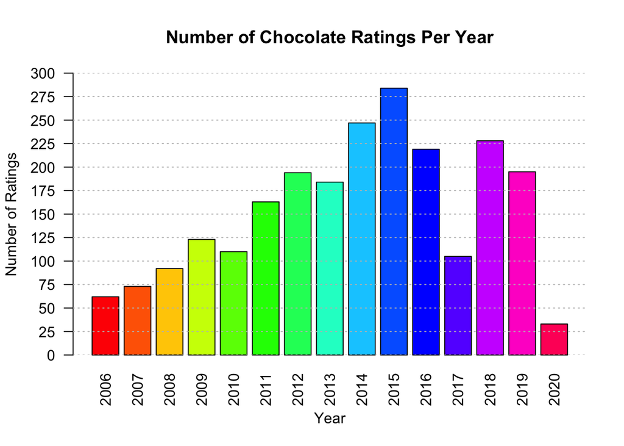

```r
df_chocoYearAndRating <- aggregate(Rating ~ Date, data=choco, FUN=length)
barplot(df_chocoYearAndRating$Rating, names.arg=df_chocoYearAndRating$Date, ylim=c(0, 300), yaxp=c(0, 300, 12), main="Number of Chocolate Ratings Per Year", xlab="Year", ylab="Number of Ratings", col=rainbow(15), las=2)
abline(h=seq(0, 300, 25), col="grey", lty="dotted")
```

#### 3. Do ratings depend on the cacao percentage of a chocolate bar?

No, because the correlation between cacao percentage and the chocolate rating is -0.1784699. Since -0.1784699 is closer to 0 than -0.8 then there is no real negative linear relationship between cacao percentage and chocolate rating. If the correlation was closer to -0.8 then it can be said even though its not completely definite that there is some sort of negative linear relationship between cacao percentage and the chocolate rating. Also, visually through the bar chart it can be seen that the average ratings just randomly oscillates between 2.00 and 3.75 regardless of increasing cacao percentage.

```r
df_chocoPercentRatingMean <- aggregate(Rating ~ Cocoa_Percent, data=choco, FUN=mean)
cor(x=df_chocoPercentRatingMean$Cocoa_Percent, y=df_chocoPercentRatingMean$Rating)
```

```
## [1] -0.1784699
```

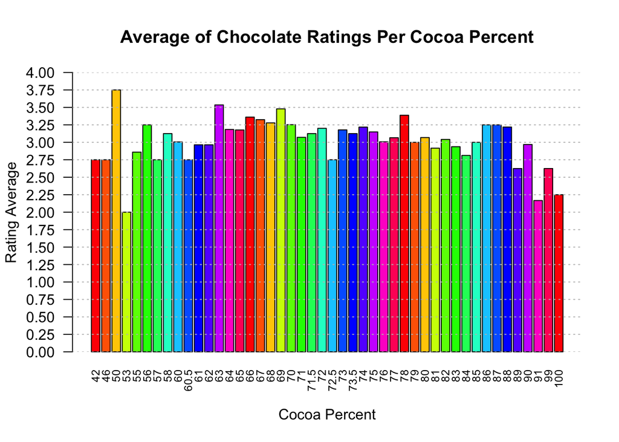

```r
barplot(df_chocoPercentRatingMean$Rating, names.arg=df_chocoPercentRatingMean$Cocoa_Percent, ylim=c(0, 4), yaxp=c(0, 4, 16), main="Average of Chocolate Ratings Per Cocoa Percent", xlab="Cocoa Percent", ylab="Rating Average", cex.names=0.75, col=rainbow(15), las=2)
abline(h=seq(0, 4, 0.25), col="grey", lty="dotted")
```

#### 4. How do different characteristics of the chocolate compare? To elaborate, which characteristics tend to be more favorable and which ones are not?

From a surface view looking at the characteristics that make up the chocolate it can be seen that characteristic 1 and 2 are tied in most favorable due to having a higher 25th percentile chocolate rating of 3.0 then next most favorable characteristic 3 with a 2.967 rating. Characteristics 1, 2, 3 all have the same average chocolate rating of 3.25 and the same 75th percentile chocolate rating of 3.5. Characteristic 4 can be seen being the least favorable because it has the lowest average rating at 3.158. Other notable things to note about the characteristics is all 4 characteristics have a maximum chocolate rating of 4.0. Characteristics 1 and 2 both have the same minimum chocolate rating of 1.0 which are the lowest minimum of the 4 characteristics when including outliers.

Diving deeper into each characteristics we can see what attributes make the individual characteristics more or less favorable. For characteristic 1 it can be seen that cardamon, chocolate covered banana, distinct lemon, large nibs, ligt color, mild tart, pronounced berry, simple red berry, smoth, sweet spice, and well defined are the most favorable attributes with a chocolate rating of 4.0. The least favorable attributes for characteristic 1 are this is not chocolate with a chocolate rating of 1.0 and klingy, high intensity bitter, and chemical each with a chocolate rating of 1.5.

For characteristic 2 it can be seen that burnt brownie, cinnamon, delicate cocoa, dense, distinquished, homey, intense pepper, long, raspberries, roasted cocoa, rounded, tart citrus, unripened fruit, wild berries, and yogurt are the most favorable attributes with a chocolate rating of 4.0. The least favorable attributes for characteristic 2 are strong off flavor with a chocolate rating of 1.0 and hint of fruit and strong chemical each with a chocolate rating of 1.5.

For characteristic 3 it can be seen that blackberry, clove, delicate fruit, gentle roast, and tangerine are the most favorable attributes with a chocolate rating of 4.0. The least favorable attributes for characteristic 3 are very bitter with a chocolate rating of 1.375 and wtf and unpleasant each with a chocolate rating of 1.5.

For characteristic 4 it can be seen that bread, cheese, olive, raspberry are the most favorable attributes with a chocolate rating of 4.0. The least favorable attributes for characteristic 4 are lemon with a chocolate rating of 2.0 and vegetal and dry each with a chocolate rating of 2.25.

##### (1) General overview of the chocolate characteristics and their ratings distribution.

```r
df_characteristic1Rating <- aggregate(Rating ~ Characteristics1, data=choco, FUN=mean)
df_characteristic2Rating <- aggregate(Rating ~ Characteristics2, data=choco, FUN=mean)
df_characteristic3Rating <- aggregate(Rating ~ Characteristics3, data=choco, FUN=mean)
df_characteristic4Rating <- aggregate(Rating ~ Characteristics4, data=choco, FUN=mean)

df_characteristic1Rating <- df_characteristic1Rating[order(-df_characteristic1Rating$Rating),]
df_characteristic2Rating <- df_characteristic2Rating[order(-df_characteristic2Rating$Rating),]
df_characteristic3Rating <- df_characteristic3Rating[order(-df_characteristic3Rating$Rating),]
df_characteristic4Rating <- df_characteristic4Rating[order(-df_characteristic4Rating$Rating),]

top <- 20
df_topCharacteristic1Rating <- head(df_characteristic1Rating, top)
df_topCharacteristic2Rating <- head(df_characteristic2Rating, top)
df_topCharacteristic3Rating <- head(df_characteristic3Rating, top)
df_topCharacteristic4Rating <- head(df_characteristic4Rating, top)

worst <- 20
df_worstCharacteristic1Rating <- tail(df_characteristic1Rating, worst)
df_worstCharacteristic2Rating <- tail(df_characteristic2Rating, worst)
df_worstCharacteristic3Rating <- tail(df_characteristic3Rating, worst)
df_worstCharacteristic4Rating <- tail(df_characteristic4Rating, worst)

summary(df_characteristic1Rating)
```

```
##  Characteristics1       Rating
##  Length:450         Min.   :1.000
##  Class :character   1st Qu.:3.000
##  Mode  :character   Median :3.250
##                     Mean   :3.178
##                     3rd Qu.:3.500
##                     Max.   :4.000
```

```r
summary(df_characteristic2Rating)
```

```
##  Characteristics2       Rating
##  Length:502         Min.   :1.000
##  Class :character   1st Qu.:3.000
##  Mode  :character   Median :3.250
##                     Mean   :3.178
##                     3rd Qu.:3.500
##                     Max.   :4.000
```

```r
summary(df_characteristic3Rating)
```

```
##  Characteristics3       Rating
##  Length:341         Min.   :1.375
##  Class :character   1st Qu.:2.967
##  Mode  :character   Median :3.250
##                     Mean   :3.172
##                     3rd Qu.:3.500
##                     Max.   :4.000
```

```r
summary(df_characteristic4Rating)
```

```
##  Characteristics4       Rating
##  Length:88          Min.   :2.000
##  Class :character   1st Qu.:2.917
##  Mode  :character   Median :3.173
##                     Mean   :3.158
##                     3rd Qu.:3.462
##                     Max.   :4.000
```

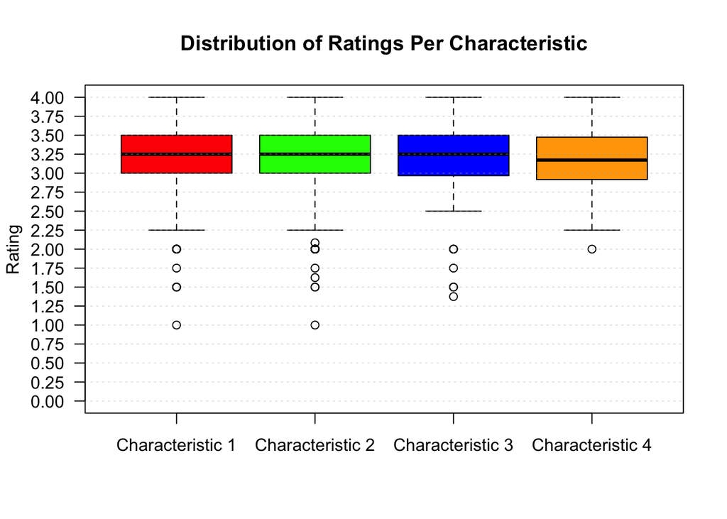

```r
boxplot(df_characteristic1Rating$Rating, df_characteristic2Rating$Rating, df_characteristic3Rating$Rating, df_characteristic4Rating$Rating, main="Distribution of Ratings Per Characteristic", names=c("Characteristic 1", "Characteristic 2", "Characteristic 3", "Characteristic 4"), ylab="Rating", ylim=c(0,4), yaxp=c(0, 4, 16), col=c("red", "green", "blue", "orange"), las=1)
abline(h=seq(0, 4, 0.25), col=alpha("grey", 0.4), lty="dotted")
```

##### (2) Top and worst 20 characteristic 1 attributes.

```r
df_topCharacteristic1Rating
```

```
##             Characteristics1 Rating
## 61                  cardamon  4.000
## 72  chocolate covered banana  4.000
## 111           distinct lemon  4.000
## 197               large nibs  4.000
## 206               ligt color  4.000
## 239                mild tart  4.000
## 293         pronounced berry  4.000
## 335         simple red berry  4.000
## 359                    smoth  4.000
## 406              sweet spice  4.000
## 443             well defined  4.000
## 284                   peanut  3.875
## 7            appealing smoke  3.750
## 8                      apple  3.750
## 30                 black tea  3.750
## 31              blackberries  3.750
## 36               bold cherry  3.750
## 39              bright fruit  3.750
## 40          bright red fruit  3.750
## 75                     cigar  3.750
```

```r
df_worstCharacteristic1Rating
```

```
##          Characteristics1   Rating
## 286               perfume 2.444444
## 62              cardboard 2.437500
## 417             too sweet 2.416667
## 50         burnt up front 2.250000
## 123       extremely sweet 2.250000
## 278          over roasted 2.250000
## 283                pastey 2.250000
## 302                   raw 2.250000
## 26   bitter coffee flavor 2.000000
## 129            fresh nibs 2.000000
## 210               malitol 2.000000
## 256  multiple off flavors 2.000000
## 261          non descript 2.000000
## 327             sandpaper 2.000000
## 362            some fruit 2.000000
## 432            very nutty 1.750000
## 68               chemical 1.500000
## 169 high intensity bitter 1.500000
## 195                klingy 1.500000
## 414 this is not chocolate 1.000000
```

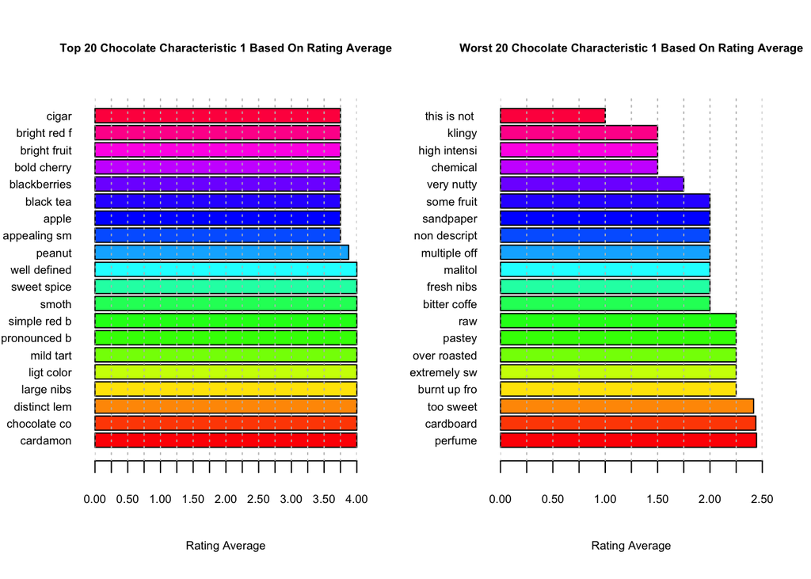

```r
par(mfrow=c(1, 2))

barplot(df_topCharacteristic1Rating$Rating, names.arg=substr(df_topCharacteristic1Rating$Characteristics1, 1, 12), horiz=TRUE,  main=paste("Top", toString(top), "Chocolate Characteristic 1 Based On Rating Average"),  xlab="Rating Average", xlim=c(0,4), xaxp=c(0, 4, 16), col=rainbow(top), cex.main=0.6, cex.names=0.6, cex.lab=0.6, cex.axis=0.6, las=1)
abline(v=seq(0, 4, 0.25), col="grey", lty="dotted")
barplot(df_worstCharacteristic1Rating$Rating, names.arg=substr(df_worstCharacteristic1Rating$Characteristics1, 1, 12), horiz=TRUE,  main=paste("Worst", toString(worst), "Chocolate Characteristic 1 Based On Rating Average"),  xlab="Rating Average", xlim=c(0,2.5), xaxp=c(0, 2.5, 10), col=rainbow(worst), cex.main=0.6, cex.names=0.6, cex.lab=0.6, cex.axis=0.6, las=1)
abline(v=seq(0, 2.5, 0.25), col="grey", lty="dotted")
```

##### (3) Top and worst 20 characteristic 2 attributes.

```r
df_topCharacteristic2Rating
```

```
##     Characteristics2   Rating
## 51     burnt brownie 4.000000
## 90          cinnamon 4.000000
## 116   delicate cocoa 4.000000
## 117            dense 4.000000
## 124    distinquished 4.000000
## 189            homey 4.000000
## 200   intense pepper 4.000000
## 224             long 4.000000
## 351      raspberries 4.000000
## 370    roasted cocoa 4.000000
## 377          rounded 4.000000
## 460      tart citrus 4.000000
## 479  unripened fruit 4.000000
## 497     wild berries 4.000000
## 502           yogurt 4.000000
## 443           subtle 3.875000
## 498             wine 3.875000
## 352        raspberry 3.791667
## 41        bright red 3.750000
## 45       brownie mix 3.750000
```

```r
df_worstCharacteristic2Rating
```

```
##       Characteristics2   Rating
## 231          medicinal 2.450000
## 381               salt 2.333333
## 198     intense coffee 2.250000
## 294              musty 2.083333
## 47             burning 2.000000
## 83  chocolate base off 2.000000
## 106         crisp nibs 2.000000
## 142        flat flavor 2.000000
## 338    poor aftertaste 2.000000
## 393        slight plum 2.000000
## 405         some fruit 2.000000
## 407         some spice 2.000000
## 478          unrefined 2.000000
## 481 vanilla domintates 2.000000
## 485         very bland 2.000000
## 126  dominate off note 1.750000
## 484        very bitter 1.625000
## 186      hint of fruit 1.500000
## 431    strong chemical 1.500000
## 435  strong off flavor 1.000000
```

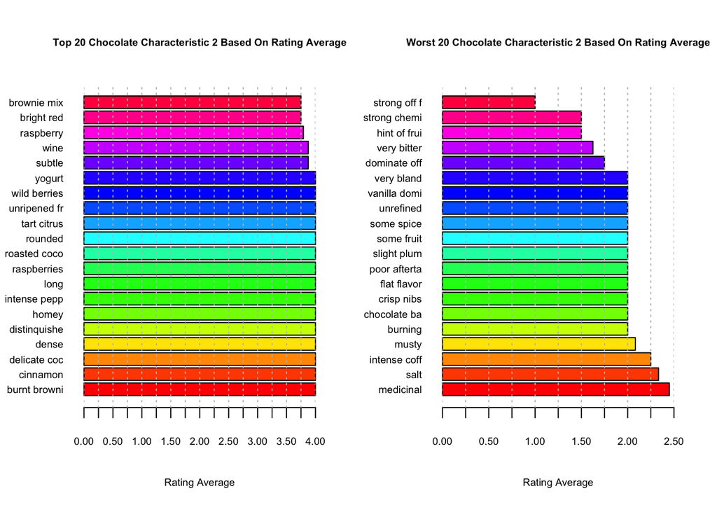

```r
par(mfrow=c(1, 2))

barplot(df_topCharacteristic2Rating$Rating, names.arg=substr(df_topCharacteristic2Rating$Characteristics2, 1, 12), horiz=TRUE,  main=paste("Top", toString(top), "Chocolate Characteristic 2 Based On Rating Average"),  xlab="Rating Average", xlim=c(0,4), xaxp=c(0, 4, 16), col=rainbow(top), cex.main=0.6, cex.names=0.6, cex.lab=0.6, cex.axis=0.6, las=1)
abline(v=seq(0, 4, 0.25), col="grey", lty="dotted")
barplot(df_worstCharacteristic2Rating$Rating, names.arg=substr(df_worstCharacteristic2Rating$Characteristics2, 1, 12), horiz=TRUE,  main=paste("Worst", toString(worst), "Chocolate Characteristic 2 Based On Rating Average"),  xlab="Rating Average", xlim=c(0,2.5), xaxp=c(0, 2.5, 10), col=rainbow(worst), cex.main=0.6, cex.names=0.6, cex.lab=0.6, cex.axis=0.6, las=1)
abline(v=seq(0, 2.5, 0.25), col="grey", lty="dotted")
```

##### (4) Top and worst 20 characteristic 3 attributes.

```r
df_topCharacteristic3Rating
```

```
##     Characteristics3 Rating
## 21        blackberry  4.000
## 65             clove  4.000
## 83    delicate fruit  4.000
## 117     gentle roast  4.000
## 306        tangerine  4.000
## 11          balanced  3.875
## 230    peanut butter  3.875
## 291       strawberry  3.875
## 18       berry notes  3.750
## 30            bright  3.750
## 40            butter  3.750
## 56             chewy  3.750
## 60        chocolatey  3.750
## 62           cinamon  3.750
## 64           classic  3.750
## 93         easy melt  3.750
## 96        fades fast  3.750
## 115        full body  3.750
## 132         hazelnut  3.750
## 141   hints of fruit  3.750
```

```r
df_worstCharacteristic3Rating
```

```
##      Characteristics3 Rating
## 57           chlorine  2.500
## 87                dry  2.500
## 89            earthen  2.500
## 109       fruit punch  2.500
## 114              fuel  2.500
## 140     hint of fruit  2.500
## 169             metal  2.500
## 208      non-descript  2.500
## 303        swiss miss  2.500
## 313          then off  2.500
## 323 vanilla dominates  2.500
## 324        vanilla(n)  2.500
## 330            walnut  2.500
## 274             soapy  2.000
## 292     strong bitter  2.000
## 335        why bother  2.000
## 319         unfixable  1.750
## 320        unpleasant  1.500
## 340               wtf  1.500
## 327       very bitter  1.375
```

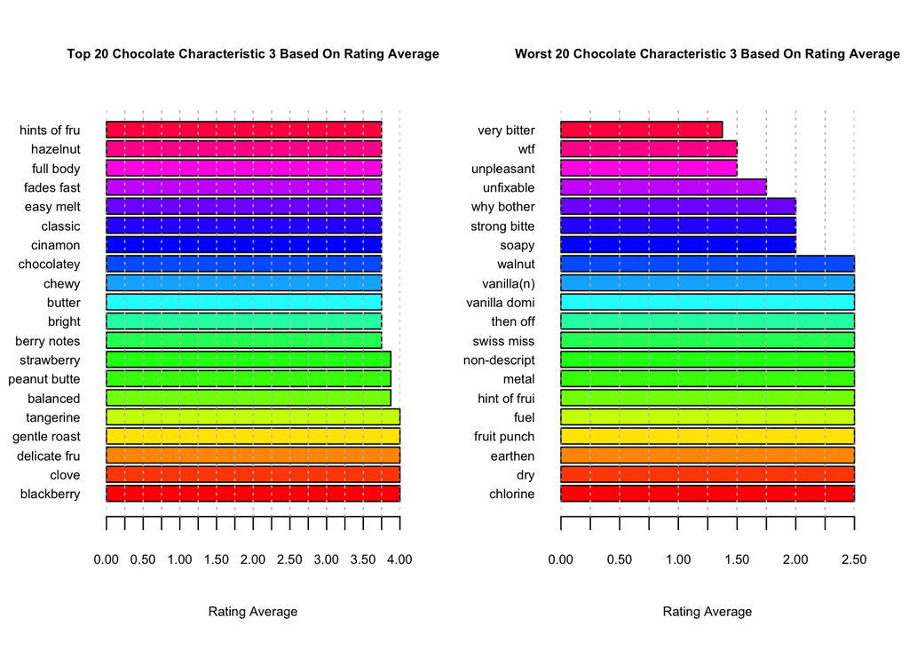

```r
par(mfrow=c(1, 2))

barplot(df_topCharacteristic3Rating$Rating, names.arg=substr(df_topCharacteristic3Rating$Characteristics3, 1, 12), horiz=TRUE,  main=paste("Top", toString(top), "Chocolate Characteristic 3 Based On Rating Average"),  xlab="Rating Average", xlim=c(0,4), xaxp=c(0, 4, 16), col=rainbow(top), cex.main=0.6, cex.names=0.6, cex.lab=0.6, cex.axis=0.6, las=1)
abline(v=seq(0, 4, 0.25), col="grey", lty="dotted")
barplot(df_worstCharacteristic3Rating$Rating, names.arg=substr(df_worstCharacteristic3Rating$Characteristics3, 1, 12), horiz=TRUE,  main=paste("Worst", toString(worst), "Chocolate Characteristic 3 Based On Rating Average"),  xlab="Rating Average", xlim=c(0,2.5), xaxp=c(0, 2.5, 10), col=rainbow(worst), cex.main=0.6, cex.names=0.6, cex.lab=0.6, cex.axis=0.6, las=1)
abline(v=seq(0, 2.5, 0.25), col="grey", lty="dotted")
```

##### (5) Top and worst 20 characteristic 4 attributes.

```r
df_topCharacteristic4Rating
```

```
##    Characteristics4   Rating
## 8             bread 4.000000
## 15           cheese 4.000000
## 60            olive 4.000000
## 66        raspberry 4.000000
## 45             long 3.875000
## 21          complex 3.750000
## 25            earth 3.750000
## 33           fruity 3.750000
## 46             malt 3.750000
## 87             wine 3.750000
## 3            banana 3.625000
## 17           citrus 3.625000
## 29              fig 3.625000
## 54              nut 3.625000
## 72            salty 3.625000
## 18            cocoa 3.593750
## 20           coffee 3.583333
## 2             apple 3.500000
## 9           brownie 3.500000
## 11            candy 3.500000
```

```r
df_worstCharacteristic4Rating
```

```
##    Characteristics4   Rating
## 13        cardboard 2.750000
## 16         chemical 2.750000
## 19          coconut 2.750000
## 30             flat 2.750000
## 34             fuel 2.750000
## 50       mild fruit 2.750000
## 52             mold 2.750000
## 57              off 2.750000
## 58         off note 2.750000
## 69           rubber 2.750000
## 74           savory 2.750000
## 75        sl. Burnt 2.750000
## 5            bitter 2.700000
## 59        off notes 2.666667
## 88            woody 2.625000
## 35            grape 2.500000
## 47        medicinal 2.500000
## 24              dry 2.250000
## 86          vegetal 2.250000
## 43            lemon 2.000000
```

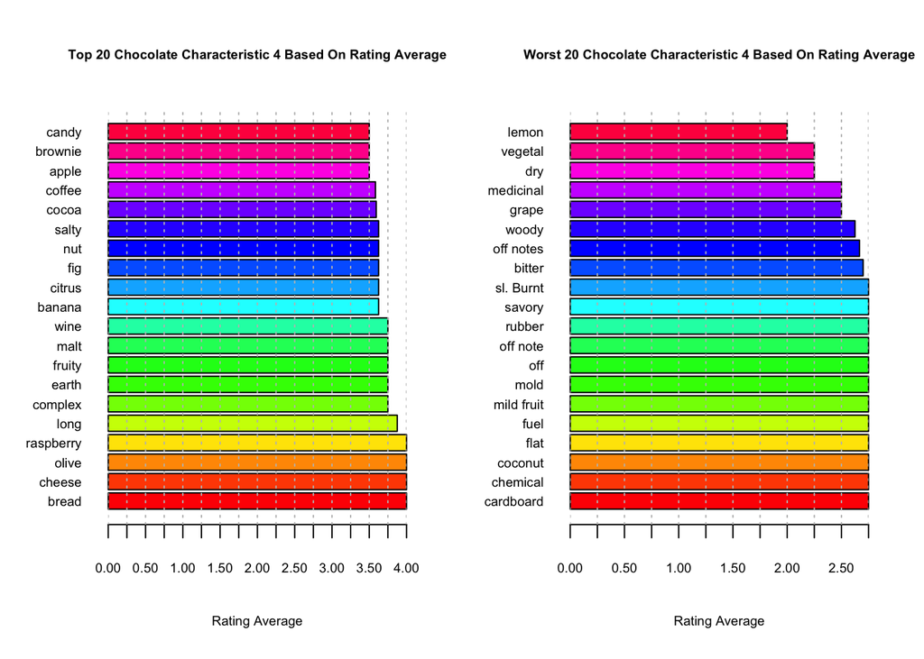

```r
par(mfrow=c(1, 2))

barplot(df_topCharacteristic4Rating$Rating, names.arg=substr(df_topCharacteristic4Rating$Characteristics4, 1, 12), horiz=TRUE,  main=paste("Top", toString(top), "Chocolate Characteristic 4 Based On Rating Average"),  xlab="Rating Average", xlim=c(0,4), xaxp=c(0, 4, 16), col=rainbow(top), cex.main=0.6, cex.names=0.6, cex.lab=0.6, cex.axis=0.6, las=1)
abline(v=seq(0, 4, 0.25), col="grey", lty="dotted")
barplot(df_worstCharacteristic4Rating$Rating, names.arg=substr(df_worstCharacteristic4Rating$Characteristics4, 1, 12), horiz=TRUE,  main=paste("Worst", toString(worst), "Chocolate Characteristic 4 Based On Rating Average"),  xlab="Rating Average", xlim=c(0,2.75), xaxp=c(0, 2.75, 11), col=rainbow(worst), cex.main=0.6, cex.names=0.6, cex.lab=0.6, cex.axis=0.6, las=1)
abline(v=seq(0, 2.75, 0.25), col="grey", lty="dotted")
```

#### 5. Brainstorm two analyses you would like to perform with your teammate. Describe in plain language what comparisons are you making. Create suitable numerical and graphical summaries for your analyses. Describe the results.

The two analysis I would like to do with my teammate is to see which beans of origin contribute to higher and lower chocolate ratings and which ingredient combinations contribute to a higher and lower chocolate ratings.

After finding the average rating per bean origin it was found that beans from Tobago had the highest rated chocolate at 3.625 and beans from St.Vincent-Grenadines had the worst rated chocolates at 2.75. Some honorable mentions for best chocolate bean origin are Sao Tome & Principe with a 3.50 rating, Solomon Islands with a 3.45 rating, and Congo with a 3.318182 rating. Some honorable mentions for worst chocolate bean origin are Puerto Rico with a 2.75 rating, Principe with a 2.75 rating, and Martinique with a 2.75 rating.

After finding the average rating per ingredient combination it was found that chocolates with the ingredients B, S, and C had the highest rated chocolates where the rating is 3.274859 and ingredients B, S*, and Sa contained in the chocolate had the lowest rating of 2.50. Some honorable mentions for other top ingredient combinations include B and S with a 3.214218 rating; B, S, C, and L with a 3.198529 rating; and B, S, and V with a 3.166667. Some honorable mentions for worst ingredient combinations include B, S, C, V, and Sa with a rating of 2.791667; B, S, and L with a rating of 2.687500; and B, S*, and Sa with a rating of 2.500000.

##### (1) Analyzing chocolate bean origin and their corresponding ratings.

```r
df_beanOriginRating <- aggregate(Rating ~ Bean_Origin, data=choco, FUN=mean)

df_beanOriginRating <- df_beanOriginRating[order(-df_beanOriginRating$Rating),]

top <- 10
worst <- 10
df_topBeanOriginRating <- head(df_beanOriginRating, top)
df_worstBeanOriginRating <- tail(df_beanOriginRating, worst)

df_topBeanOriginRating
```

```
##            Bean_Origin   Rating
## 56              Tobago 3.625000
## 44 Sao Tome & Principe 3.500000
## 46     Solomon Islands 3.450000
## 11               Congo 3.318182
## 55            Thailand 3.300000
## 13                Cuba 3.291667
## 22           Guatemala 3.273585
## 23               Haiti 3.270833
## 37    Papua New Guinea 3.270408
## 30          Madagascar 3.260736
```

```r
df_worstBeanOriginRating
```

```
##              Bean_Origin   Rating
## 48             St. Lucia 2.950000
## 47             Sri Lanka 2.875000
## 53                Taiwan 2.875000
## 60                Uganda 2.840909
## 45          Sierra Leone 2.833333
## 27           Ivory Coast 2.800000
## 32            Martinique 2.750000
## 40              Principe 2.750000
## 41           Puerto Rico 2.750000
## 49 St.Vincent-Grenadines 2.750000
```

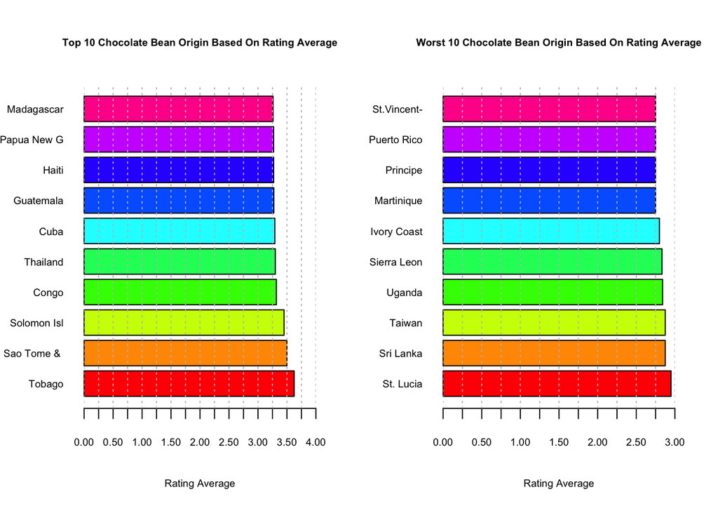

```r
par(mfrow=c(1, 2))

barplot(df_topBeanOriginRating$Rating, names.arg=substr(df_topBeanOriginRating$Bean_Origin, 1, 11), horiz=TRUE,  main=paste("Top", toString(top), "Chocolate Bean Origin Based On Rating Average"), xlab="Rating Average", xlim=c(0,4), xaxp=c(0, 4, 16), col=rainbow(top), cex.main=0.6, cex.names=0.6, cex.lab=0.6, cex.axis=0.6, las=1)
abline(v=seq(0, 4, 0.25), col="grey", lty="dotted")
barplot(df_worstBeanOriginRating$Rating, names.arg=substr(df_worstBeanOriginRating$Bean_Origin, 1, 11), horiz=TRUE,  main=paste("Worst", toString(worst), "Chocolate Bean Origin Based On Rating Average"), xlab="Rating Average", xlim=c(0,3), xaxp=c(0, 3, 12), col=rainbow(worst), cex.main=0.6, cex.names=0.6, cex.lab=0.6, cex.axis=0.6, las=1)
abline(v=seq(0, 3, 0.25), col="grey", lty="dotted")
```

##### (2) Analyzing chocolate ingredients and their corresponding ratings.

```r
df_ingredientsRating <- aggregate(Rating ~ Ingredients, data=choco, FUN=mean)

df_ingredientsRating <- df_ingredientsRating[order(-df_ingredientsRating$Rating),]

top <- 10
worst <- 10
df_topIngredientsRating <- head(df_ingredientsRating, top)
df_worstIngredientsRating <- tail(df_ingredientsRating, worst)

df_topIngredientsRating
```

```
##     Ingredients   Rating
## 5      3- B,S,C 3.274859
## 3        2- B,S 3.214218
## 10   4- B,S,C,L 3.198529
## 7      3- B,S,V 3.166667
## 11  4- B,S,C,Sa 3.150000
## 15 4- B,S*,C,Sa 3.112500
## 19 5- B,S,C,V,L 3.089674
## 17  4- B,S*,V,L 3.083333
## 2        2- B,C 3.000000
## 16  4- B,S*,C,V 3.000000
```

```r
df_worstIngredientsRating
```

```
##       Ingredients   Rating
## 12     4- B,S,C,V 2.970588
## 4         2- B,S* 2.959677
## 1            1- B 2.950000
## 8       3- B,S*,C 2.937500
## 21 6-B,S,C,V,L,Sa 2.937500
## 13     4- B,S,V,L 2.900000
## 14    4- B,S*,C,L 2.875000
## 20   5-B,S,C,V,Sa 2.791667
## 6        3- B,S,L 2.687500
## 9      3- B,S*,Sa 2.500000
```

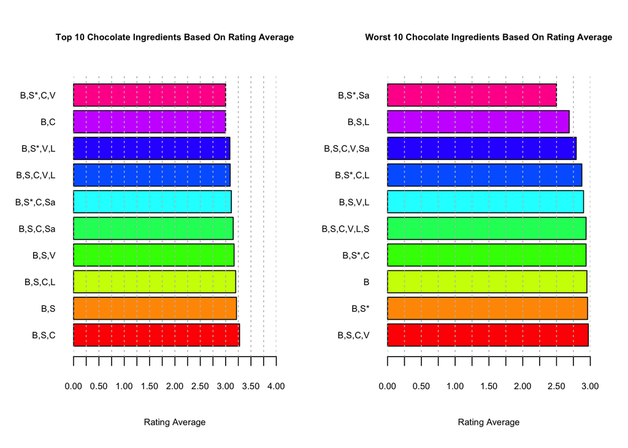

```r
par(mfrow=c(1, 2))

barplot(df_topIngredientsRating$Rating, names.arg=substr(df_topIngredientsRating$Ingredients, 3, 13), horiz=TRUE,  main=paste("Top", toString(top), "Chocolate Ingredients Based On Rating Average"), xlab="Rating Average", xlim=c(0,4), xaxp=c(0, 4, 16), col=rainbow(top), cex.main=0.6, cex.names=0.6, cex.lab=0.6, cex.axis=0.6, las=1)
abline(v=seq(0, 4, 0.25), col="grey", lty="dotted")
barplot(df_worstIngredientsRating$Rating, names.arg=substr(df_worstIngredientsRating$Ingredients, 3, 13), horiz=TRUE,  main=paste("Worst", toString(worst), "Chocolate Ingredients Based On Rating Average"), xlab="Rating Average", xlim=c(0,3), xaxp=c(0, 3, 12), col=rainbow(worst), cex.main=0.6, cex.names=0.6, cex.lab=0.6, cex.axis=0.6, las=1)
abline(v=seq(0, 3, 0.25), col="grey", lty="dotted")
```